# Anaconda Navigator - "open ecosystem for sourcing, building, and deploying data science and AI initiatives"

## dostupno na: https://www.anaconda.com/download

# Pokretanje Jupyter Notebooka

[figure not shown]

## Jupyter Dashboard

### radni prostor za upravljanje Jupyter notebookovima

[figure not shown]

### Jupyter dashboard se prvi pokreće i u njemu određujemo lokaciju pohrane našeg koda kao i mjesto gdje uploadamo naše datasetove

Po defaultu, vidimo foldere koji su određeni u Jupyter notebook start up lokaciji - kod mene C:\Users

# Stvaranje novog foldera ili pokretanje novog Python filea

[figure not shown]

# Rad u Jupyter Notebooku

## Alat s dvostrukom namjenom - razvoj i prezentiranje data science projekata

Za razliku od drugih razvojnih okolina u kojima se komentari ne mogu uređivati, Jupyter notebook omogućuje uređivanje teksta, stavljanje slika, formatiranje dijelova teksta i sl

## Jupyter Notebook omogućuje

- kodiranje
- prikaz rezultata
- dodavanje objašnjenja
- dodavanje formula
- dodavanje grafikona

Za uređivanje teksta koristimo **Markdown** (*Markdown is a lightweight markup language for creating formatted text using a plain-text editor*)

### Upute za uređenje Markdowna se nalaze na ovom [Github linku](https://docs.github.com/en/get-started/writing-on-github/getting-started-with-writing-and-formatting-on-github/basic-writing-and-formatting-syntax)

### uputama se može pristupiti i ovdje:

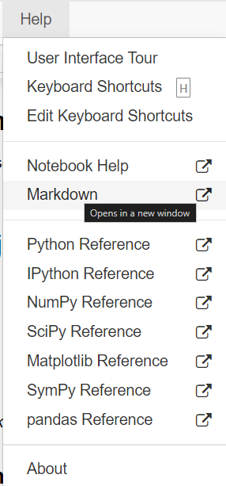

## Dvije vrste ćelija u Jupyter notebooku

### - ćelija za kodiranje - ćelija u kojoj se nalazi kod čiji rezultat se prikazuje ispod te ćelije nakon izvršavanja

### - ćelija za Markdown - ćelija koja sadrži tekst po pravilima Markdowna, omogućuje nam lakše razumijevanje čitavog projekta. I za programera i za one koji gledaju rezultate

### prebacivanje između ove dvije vrste ćelija se odvija lijevim klikom miša lijevo od ćelije i klikom na slovo M na tipkovnici za Markdown, odnosno Y za kod

## pokretanje koda u Pythonu - nakom što se natipka, koristi se kombinacija tipaka Shift + Enter

```python
print ("Hello world!")
```

```
Hello world!
```

# Kratke upute za Markdown - kliknuti lijevo od ćelije i stisnuti M

# korištenje jednog hashtaga na početku (#) za Heading 1

## korištenje dva hashtaga na početku (##) za Heading 2

### korištenje tri hashtaga na početku (###) za Heading 3

bez hashtaga - običan tekst

korištenjem crtice ispred natuknica imamo nabrajanje (-)

- nabrajamo
- nabrajamo
- i još malo nabrajamo

ako koristimo dvije zvjezdice **prije i poslije teksta, boldamo ga** ( ** ) ako korstimo underscore *prije i poslije teksta*, radimo italic

Slika: drag and drop iz foldera na računalu ili ctrl + C i ctrl + V s neta

[figure not shown]

# **Zadatak 1 - kodiranje**

## Korištenjem Pythona, u ćeliji za kodiranje napravite listu od 5 elemenata (integer i string) te korištenjem naredbe print ispišite njen sadržaj

```python
moja_lista = [15, "Zagreb", "Lipik", 1999, 22]
```

```python
print (moja_lista)
```

```
[15, 'Zagreb', 'Lipik', 1999, 22]
```

# **Zadatak 2 - kodiranje**

### - U ćeliji za kodiranje napravite kod u kome vas Python pita za vaše ime. Odgovor pohranite u varijabli 'ime'.

### - Python vas pita i za vaše godine, odgovor pohranite u varijabli 'godine'.

### - Definirajte novu varijablu 'godina_rodjenja' koju ćete izračunati na osnovu starosti.

### - Na kraju ispisat će se na ekranu:

### - Pozdrav 'ime" rodjeni ste 'godina_rodjenja' godine!

```python
ime = input("Kako se zovete? ")
```

```
Kako se zovete? Igor
```

```python
print (ime)
```

```
Igor
```

```python
godine = input("Koliko imate godina? ")
```

```
Koliko imate godina? 45
```

```python
print (godine)
```

```
45
```

```python
type(godine)
```

```
str
```

```python
godina_rodjenja = 2024 - int(godine)
```

```python
print (godina_rodjenja)
```

```
1979
```

```python
print ('Pozdrav ', ime, 'rodjeni ste ', godina_rodjenja, 'godine')
```

```
Pozdrav  Igor rodjeni ste  1979 godine
```

# **Zadatak 3 - markdown**

## korištenjem markdowna napišite o čemu se radi u filmu Titanic!

# Dataset Titanic

## Popis putnika na brodu Titanic i njihovi podaci (spol, godište, razred u kojem su putovali, broj djece s kojima su putovali, cijena karte, jesu li preživjeli)

## Koristi se za učenje eksplorativne analize podataka (EDA - exploatory data analysis)

# EDA se koristi na početku data science projekta kako bismo se upoznali s podacima, njihovom distribucijom, vezama među podacima, različitim obrascima koji se pojavljuju

## EDA se koristi kako bi se pronašle i popravile greške unutar podataka - nedostajuće vrijednosti, ekstremne vrijednosti, pogrešno unešene vrijednosti, duplikati

```python
import pandas as pd
```

# Za razliku od drugih razvojnih okruženja, Jupyter već ima instalirane module za data science

```python
putnici = pd.read_csv ("titanic.csv")
```

# Kako bi se vaš book mogao povezati s datasetom i učitati podatke, datoteka titanic.csv mora biti u istom folderu

# Koristimo naredbu Upload

[figure not shown]

```python
putnici.head()
```

|  | Survived | Pclass | Name | Sex | Age | Siblings/Spouses Aboard | Parents/Children Aboard | Fare |
| --- | --- | --- | --- | --- | --- | --- | --- | --- |
| 0 | 0 | 3 | Mr. Owen Harris Braund | male | 22.0 | 1 | 0 | 7.2500 |
| 1 | 1 | 1 | Mrs. John Bradley (Florence Briggs Thayer) Cum... | female | 38.0 | 1 | 0 | 71.2833 |
| 2 | 1 | 3 | Miss. Laina Heikkinen | female | 26.0 | 0 | 0 | 7.9250 |
| 3 | 1 | 1 | Mrs. Jacques Heath (Lily May Peel) Futrelle | female | 35.0 | 1 | 0 | 53.1000 |
| 4 | 0 | 3 | Mr. William Henry Allen | male | 35.0 | 0 | 0 | 8.0500 |

## Koristimo Pandas library - biblioteka koja se koristi za rad s datasetovima i njihovom analizom, čišćenjem i manipulacijom

## Pandas je popularan jer podržava mnoštvo formata i omogućuje pregled podataka u tabularnom obliku

## podatke koje dobijemo Pandas pohranjuje u dataframeu

# **Zadatak 4**

## koje sve formate podataka možete učitati korištenjem pd.read naredbe

## Kako se mijenja kraj naredbe pd.read, ovisno o formatu (comma separated file, excel file, json file)?

```python
putnici.info()
```

```
<class 'pandas.core.frame.DataFrame'>
RangeIndex: 887 entries, 0 to 886
Data columns (total 8 columns):
 #   Column                   Non-Null Count  Dtype
---  ------                   --------------  -----
 0   Survived                 887 non-null    int64
 1   Pclass                   887 non-null    int64
 2   Name                     887 non-null    object
 3   Sex                      887 non-null    object
 4   Age                      887 non-null    float64
 5   Siblings/Spouses Aboard  887 non-null    int64
 6   Parents/Children Aboard  887 non-null    int64
 7   Fare                     887 non-null    float64
dtypes: float64(2), int64(4), object(2)
memory usage: 55.6+ KB
```

```python
putnici.tail()
```

|  | Survived | Pclass | Name | Sex | Age | Siblings/Spouses Aboard | Parents/Children Aboard | Fare |
| --- | --- | --- | --- | --- | --- | --- | --- | --- |
| 882 | 0 | 2 | Rev. Juozas Montvila | male | 27.0 | 0 | 0 | 13.00 |
| 883 | 1 | 1 | Miss. Margaret Edith Graham | female | 19.0 | 0 | 0 | 30.00 |
| 884 | 0 | 3 | Miss. Catherine Helen Johnston | female | 7.0 | 1 | 2 | 23.45 |
| 885 | 1 | 1 | Mr. Karl Howell Behr | male | 26.0 | 0 | 0 | 30.00 |
| 886 | 0 | 3 | Mr. Patrick Dooley | male | 32.0 | 0 | 0 | 7.75 |

```python
putnici.describe()
```

|  | Survived | Pclass | Age | Siblings/Spouses Aboard | Parents/Children Aboard | Fare |
| --- | --- | --- | --- | --- | --- | --- |
| count | 887.000000 | 887.000000 | 887.000000 | 887.000000 | 887.000000 | 887.00000 |
| mean | 0.385569 | 2.305524 | 29.471443 | 0.525366 | 0.383315 | 32.30542 |
| std | 0.487004 | 0.836662 | 14.121908 | 1.104669 | 0.807466 | 49.78204 |
| min | 0.000000 | 1.000000 | 0.420000 | 0.000000 | 0.000000 | 0.00000 |
| 25% | 0.000000 | 2.000000 | 20.250000 | 0.000000 | 0.000000 | 7.92500 |
| 50% | 0.000000 | 3.000000 | 28.000000 | 0.000000 | 0.000000 | 14.45420 |
| 75% | 1.000000 | 3.000000 | 38.000000 | 1.000000 | 0.000000 | 31.13750 |
| max | 1.000000 | 3.000000 | 80.000000 | 8.000000 | 6.000000 | 512.32920 |

## objasnite što vidimo u gornjoj tablici

## što znači mean, std, max, min

### objasnite pojam standardne devijacije

```python
putnici ["Sex"].describe()
```

```
count      887
unique       2
top       male
freq       573
Name: Sex, dtype: object
```

### kako dobiti podatke o broju muškaraca i žena na Titaniku

```python
putnici.Sex.value_counts()
```

```
Sex
male      573
female    314
Name: count, dtype: int64
```

# **Zadatak 5**

- prikažite koliko je putnika putovalo po pojedinom razredu
- prikažite koliko je osoba preživjelo / nije preživjelo

```python
putnici.Survived.value_counts()
```

```
Survived
0    545
1    342
Name: count, dtype: int64
```

```python
putnici.Pclass.value_counts()
```

```
Pclass
3    487
1    216
2    184
Name: count, dtype: int64
```

## Kako dobiti maksimalnu / prosječnu vrijednost za starost ili cijenu karte, po spolu ili po razredu putovanja?

## Koristimo grupiranje (naredba groupby) i radimo podskup u obliku novog dataseta

```python
putnici_group_Pclass = putnici.groupby ("Pclass")
```

```python
putnici_group_Pclass.head()
```

|  | Survived | Pclass | Name | Sex | Age | Siblings/Spouses Aboard | Parents/Children Aboard | Fare |
| --- | --- | --- | --- | --- | --- | --- | --- | --- |
| 0 | 0 | 3 | Mr. Owen Harris Braund | male | 22.0 | 1 | 0 | 7.2500 |
| 1 | 1 | 1 | Mrs. John Bradley (Florence Briggs Thayer) Cum... | female | 38.0 | 1 | 0 | 71.2833 |
| 2 | 1 | 3 | Miss. Laina Heikkinen | female | 26.0 | 0 | 0 | 7.9250 |
| 3 | 1 | 1 | Mrs. Jacques Heath (Lily May Peel) Futrelle | female | 35.0 | 1 | 0 | 53.1000 |
| 4 | 0 | 3 | Mr. William Henry Allen | male | 35.0 | 0 | 0 | 8.0500 |
| 5 | 0 | 3 | Mr. James Moran | male | 27.0 | 0 | 0 | 8.4583 |
| 6 | 0 | 1 | Mr. Timothy J McCarthy | male | 54.0 | 0 | 0 | 51.8625 |
| 7 | 0 | 3 | Master. Gosta Leonard Palsson | male | 2.0 | 3 | 1 | 21.0750 |
| 9 | 1 | 2 | Mrs. Nicholas (Adele Achem) Nasser | female | 14.0 | 1 | 0 | 30.0708 |
| 11 | 1 | 1 | Miss. Elizabeth Bonnell | female | 58.0 | 0 | 0 | 26.5500 |
| 15 | 1 | 2 | Mrs. (Mary D Kingcome) Hewlett | female | 55.0 | 0 | 0 | 16.0000 |
| 17 | 1 | 2 | Mr. Charles Eugene Williams | male | 23.0 | 0 | 0 | 13.0000 |
| 20 | 0 | 2 | Mr. Joseph J Fynney | male | 35.0 | 0 | 0 | 26.0000 |
| 21 | 1 | 2 | Mr. Lawrence Beesley | male | 34.0 | 0 | 0 | 13.0000 |
| 23 | 1 | 1 | Mr. William Thompson Sloper | male | 28.0 | 0 | 0 | 35.5000 |

```python
putnici_group_Pclass ["Age"].max()
```

```
Pclass
1    80.0
2    70.0
3    74.0
Name: Age, dtype: float64
```

```python
putnici_group_Pclass ["Fare"].mean()
```

```
Pclass
1    84.154687
2    20.662183
3    13.707707
Name: Fare, dtype: float64
```

```python
putnici_group_Pclass ["Survived"].value_counts()
```

```
Pclass  Survived
1       1           136
        0            80
2       0            97
        1            87
3       0           368
        1           119
Name: count, dtype: int64
```

## Gledajući razred putovanja, iz kojeg razreda su bile veće šanse za preživljavanje?

# **Zadatak 6**

## grupirajte početne podatke po spolu i prikažite koliko je preživjelo muškaraca, a koliko žena?

```python
putnici_group_Sex = putnici.groupby ("Sex")
```

```python
putnici_group_Sex ["Age"].min()
```

```
Sex
female    0.75
male      0.42
Name: Age, dtype: float64
```

```python
putnici_group_Sex ["Survived"].value_counts()
```

```
Sex     Survived
female  1           233
        0            81
male    0           464
        1           109
Name: count, dtype: int64
```

## Podaci se mogu grupirati i po više varijabli

```python
putnici_group_PS = putnici.groupby (["Pclass", "Sex"])
```

```python
putnici_group_PS ["Fare"].mean()
```

```
Pclass  Sex
1       female    106.125798
        male       67.226127
2       female     21.970121
        male       19.741782
3       female     16.118810
        male       12.695466
Name: Fare, dtype: float64
```

```python
putnici_group_PS ["Fare"].agg (["count", "mean", "max", "min"])
```

| Pclass | Sex | count | mean | max | min |
| --- | --- | --- | --- | --- | --- |
| 1 | female | 94 | 106.125798 | 512.3292 | 25.9292 |
|  | male | 122 | 67.226127 | 512.3292 | 0.0000 |
| 2 | female | 76 | 21.970121 | 65.0000 | 10.5000 |
|  | male | 108 | 19.741782 | 73.5000 | 0.0000 |
| 3 | female | 144 | 16.118810 | 69.5500 | 6.7500 |
|  | male | 343 | 12.695466 | 69.5500 | 0.0000 |

## Vidimo u podacima kako su pojedini muškarci putovali besplatno, dok su žene morale plaćati kartu. Što mislite zašto?

# **Zadatak 7**

## učitajte dataset osiguranici i napravite osnovnu analizu!

```python
osiguranici = pd.read_csv ("osiguranici.csv")
```

```python
osiguranici.head()
```

|  | City | Gender | Age | Income | Illness |
| --- | --- | --- | --- | --- | --- |
| 0 | Dallas | Male | 41 | 40367.0 | No |
| 1 | Dallas | Male | 54 | 45084.0 | No |
| 2 | Dallas | Male | 42 | 52483.0 | No |
| 3 | Dallas | Male | 40 | 40941.0 | No |
| 4 | Dallas | Male | 46 | 50289.0 | No |

```python
osiguranici.Illness.value_counts()
```

```
Illness
No     137861
Yes     12139
Name: count, dtype: int64
```

# Učitajte dataset bike_buyers_clean i napravite osnovnu analizu

```python
bicikli = pd.read_csv ("bike_buyers_clean.csv")
```

```python
bicikli.head()
```

|  | ID | Marital Status | Gender | Income | Children | Education | Occupation | Home Owner | Cars | Commute Distance | Region | Age | Purchased Bike |
| --- | --- | --- | --- | --- | --- | --- | --- | --- | --- | --- | --- | --- | --- |
| 0 | 12496 | Married | Female | 40000 | 1 | Bachelors | Skilled Manual | Yes | 0 | 0-1 Miles | Europe | 42 | No |
| 1 | 24107 | Married | Male | 30000 | 3 | Partial College | Clerical | Yes | 1 | 0-1 Miles | Europe | 43 | No |
| 2 | 14177 | Married | Male | 80000 | 5 | Partial College | Professional | No | 2 | 2-5 Miles | Europe | 60 | No |
| 3 | 24381 | Single | Male | 70000 | 0 | Bachelors | Professional | Yes | 1 | 5-10 Miles | Pacific | 41 | Yes |
| 4 | 25597 | Single | Male | 30000 | 0 | Bachelors | Clerical | No | 0 | 0-1 Miles | Europe | 36 | Yes |